# Fixing the pedigree with kinship

Alexandros Topaloudis

# Purpose statement

This document serves a double purpose. A log of how I manually curated our pedigree links using genomic data and a script to replicate the process. You require the things loaded in the following code block (3 packages) and some files all of which can be found [here](https://github.com/topalw/pedigree) :

- 3 table files originating from a gds file *(might want to incorporate code here!)*
- a total pedigree from the barn owl database
- a metadata file with sample names and populations in the reference panel

```r
library(kinship2) # pedigree making +
library(corrplot) # well....corrplots
library(knitr) # kable !
metadata <- read.csv('refpanel_metadata.csv')
b <- read.table('swiss_beta_matrix.table') # b-eta table of kinship
b <- b[-which(rownames(b)=='877825F2'),-which(rownames(b)=='877825F2')] #to avoid duplicated issue
rownames(b) <- metadata$NEWname[match(rownames(b),metadata$rawVCFname)]
k0 <- read.table('ref_panel_k0.table')
k1 <- read.table('ref_panel_k1.table')
p <- read.csv('total_pedigree_052022.csv') # p-edigree
dp <- read.delim('depth_stats_all.idepth') # D-epth
```

# The process

A way to start is with a comparison of the pedigree inferred kinship matrix and the genomic kinship matrix. Intuitively the difference of values observed for each cell should be just due to recombinational variance from generation to generation (pedigree kinship is simply the expected value instead of the realized Speed & Balding 2015 - Table 1). However big deviations will be due to incorrect pedigree links or sequencing errors. It is sometimes hard to differentiate the two but for most cases use of multiple anchor points (comparing beta with 2-3 individuals should clarify the causes). You will see that we have both in our dataset!

Originally, since Sonia has worked a bit on adding the hubs in the core family pedigree I simply started from there which led to a more complicated process. I will now attempt to redo the procedure in a simpler manner by utilizing the pedigree - genomic comparison only. I expect the same results.

Lets make some kinship matrices, index them and identify differences.

```r
kp <- kinship(p$id,p$dadid,p$momid)  # swiss pedigree kinship matrix
binp <- match(rownames(b), rownames(kp)) # get index of sequenced samples in kp
kp <- kp[binp,binp] # subset pedigree matrix to include only sequenced samples
```

Since I might want to calculate differences many times I will create a function that does this.

```r
# return difference matrix
diff.k <- function(mat1, mat2){
  if(setequal(rownames(mat1),rownames(mat2))){
  d1 <- as.matrix(mat1 - mat2)
  return(d1)
  }else { print('matrix missmatch')}
}
# color transparency function by Tristan
add.alpha <- function(col, alpha=1){
  if(missing(col))
    stop("Please provide a vector of colours.")
  apply(sapply(col, col2rgb)/255, 2,
        function(x)
          rgb(x[1], x[2], x[3], alpha=alpha))
}
#plotting function
plot.diff <- function(d.mat,cutoff){
  #corrplot(d.mat, method='shade',type='upper',tl.pos='n',is.corr=F,diag=F)
  plot(d.mat[upper.tri(d.mat,diag=T)], pch=20, col = add.alpha('black',0.6),cex=0.6,
       ylab='pedigree - genetic kinship',ylim =c(-0.5,0.5))
  abline(h=cutoff,lty=2,col='red')
  abline(h=-cutoff,lty=2,col='red')
}
```

Lets visualize the initial differences of ped and b.

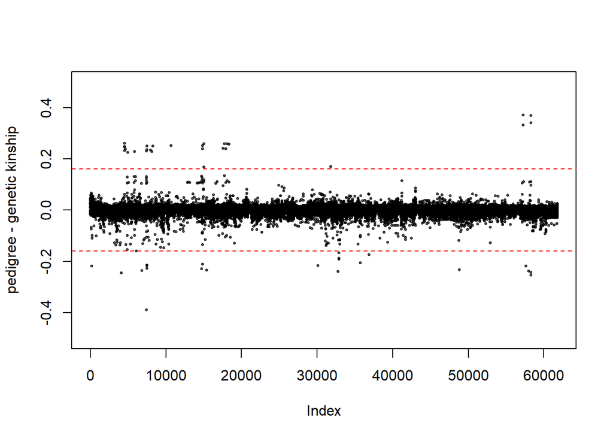

```r
d <- diff.k(kp,b)
plot.diff(d,0.16)
```

Now we can identify these pairs of individuals that lead to most extreme differences (abs(k.diff)>0.16) and the reason we only consider these differences is because they are probably the only ones we can correct since 2 degrees of relatedness are much harder to infer.  
We will treat all errors separately but our tools are the same. Pairwise b estimation of individuals and their relatives, k0-k1 plots to identify type of 1st degree links (P-O or Siblings) and the first year individuals were observed (example if an individual was observed in 2014 and another in 2016 and we observe a P-O link we know the 2014 has to be the parent ;) )

```r
# cheat and make lower part 0 to escape having the same broken link twice!
tmpd <- d
tmpd[lower.tri(tmpd)] <- 0
bl <- data.frame(which(abs(tmpd) >= 0.16, arr.ind=T),row.names = NULL) #bl == broken links
#fix dataframe a bit
bl$row <- rownames(b)[bl$row]
bl$col <- rownames(b)[bl$col]
colnames(bl) <- c('ind1','ind2')
# add beta information
bl$bg <- 0 # beta genome
bl$bp <- 0 # beta pedigree
for(i in 1:nrow(bl)){ # fancy loop a foolproof way of doing it
  bl$bg[i] <- b[match(bl$ind1[i],rownames(b)), match(bl$ind2[i],rownames(b))]
  bl$bp[i] <- kp[match(bl$ind1[i],rownames(kp)), match(bl$ind2[i],rownames(kp))]
}
kable(bl[1:10,],caption='Bad links')
```

Bad links

| ind1 | ind2 | bg | bp |
| --- | --- | --- | --- |
| 875626 | 877861 | 0.2177817 | 0.00 |
| M001670 | M005026 | 0.2447667 | 0.00 |
| 898172 | M005221 | 0.0172396 | 0.25 |
| 898350 | M005221 | -0.0095922 | 0.25 |
| M005219 | M005221 | 0.0034476 | 0.25 |
| M005220 | M005221 | 0.0025978 | 0.25 |
| M005221 | M005222 | 0.0135618 | 0.25 |
| M005188 | M005447 | 0.0248183 | 0.25 |
| M005188 | M011005 | 0.0222689 | 0.25 |
| 895274 | M011142 | 0.2363940 | 0.00 |

This table needs to be reduced to 0 based on manual inspection. A daunting task. Dirty work. Terrible endeavor. Let’s do it!

We can start by identifying clusters of bad links that are created by 1 individual misclasified in the pedigree and correcting those.

- M005221 case - For example the individual M005221 observed in the head above! That guy is unrelated with his family (identified previously during family reconstruction but since I am redoing everything here I can also document those broken links (FML)). This guy also has no other relatives in the beta matrix of genomic kinship so we might as well consider him an unrelated individual.  
  Now the way to correct this guy would be to update the pedigreee information. However we cannot do this in a subset pedigree that only includes sequenced individuals since that pedigree might infer erroneous kinship because of missing individuals (think of F2 cousins where F0 was not sequenced and is thus missing). Thus we make a copy of the total pedigree and we modify that accordingly. For this case we just set the parents to founders!

```r
# M0052221
# which(b[rownames(b)=='M005221',] > 0.16 ) # only the diagonal
mp <- p[c(1,2,3,5)] # modified pedigree
mp[mp$id == 'M005221', c(2,3)] <- c(NA,NA)
mp[mp$id == 'M005221',] #  fixed !
```

|  | id | dadid | momid | sex |
| --- | --- | --- | --- | --- |
| 4650 | M005221 | NA | NA | 1 |

Obviously now we need to update the difference dataset with the new pedigree so we make a function that does that and we persevere.

```r
# beast fuction to update difference dataset everytime we modify an individual
update.diff <- function(mp,b){ # takes a pedigree and a beta matrix
  mpk <- kinship(mp$id,mp$dadid,mp$momid) # get kinship
  binmp <- match(rownames(b), rownames(mpk)) # matches
  mpk <- mpk[binmp,binmp]
  tmpd <- diff.k(mpk,b) # makes difference
  # does what {r check df of bad links} does !
  tmpd[lower.tri(tmpd)] <- 0
  bl <- data.frame(which(abs(tmpd) >= 0.16, arr.ind=T),row.names = NULL)
  bl$row <- rownames(b)[bl$row]
  bl$col <- rownames(b)[bl$col]
  colnames(bl) <- c('ind1','ind2')
  bl$bg <- 0
  bl$bp <- 0
  for(i in 1:nrow(bl)){
   bl$bg[i] <- b[match(bl$ind1[i],rownames(b)), match(bl$ind2[i],rownames(b))]
   bl$bp[i] <- mpk[match(bl$ind1[i],rownames(mpk)), match(bl$ind2[i],rownames(mpk))]
  }
  return(bl)
}
#function to make founder line for ped
add.founder <- function(id,sex=1){
  return(data.frame('id'=id,'dadid'=rep(NA,length(id)),'momid'=rep(NA,length(id)),'sex'=rep(sex,length(id))))
}
bl <- update.diff(mp,b)
kable(bl,caption = 'Bad links - update1' )
```

Bad links - update1

| ind1 | ind2 | bg | bp |
| --- | --- | --- | --- |
| 875626 | 877861 | 0.2177817 | 0.0000 |
| M001670 | M005026 | 0.2447667 | 0.0000 |
| M005188 | M005447 | 0.0248183 | 0.2500 |
| M005188 | M011005 | 0.0222689 | 0.2500 |
| 895274 | M011142 | 0.2363940 | 0.0000 |
| 898075 | M011192 | 0.0206807 | 0.2500 |
| 898172 | M011192 | 0.3887892 | 0.0000 |
| M005219 | M011192 | 0.2161238 | 0.0000 |
| M005220 | M011192 | 0.2152322 | 0.0000 |
| M005222 | M011192 | 0.2275754 | 0.0000 |
| M005673 | M011192 | -0.0003835 | 0.2500 |
| M011188 | M011192 | 0.0138543 | 0.2500 |
| M011192 | M011736 | 0.0159162 | 0.2500 |
| M011192 | M011740 | 0.0210986 | 0.2500 |
| M011192 | M011741 | 0.0006335 | 0.2500 |
| M011681 | M022193 | -0.0020414 | 0.2500 |
| M026357 | M026361 | 0.4789669 | 0.2500 |
| M014481 | M026451 | 0.2115683 | 0.0000 |
| M022113 | M026451 | 0.0114581 | 0.2500 |
| M022135 | M026451 | -0.0021250 | 0.2500 |
| M026451 | M026452 | -0.0092021 | 0.2500 |
| M026452 | M026452 | 0.3318238 | 0.5000 |
| M026451 | M026478 | 0.2340117 | 0.0000 |
| M026451 | M026960 | 0.0096053 | 0.2500 |
| M026451 | M026961 | -0.0094528 | 0.2500 |
| M026451 | M026962 | 0.0114303 | 0.2500 |
| M026451 | M026963 | -0.0086030 | 0.2500 |
| M026451 | M026964 | -0.0074328 | 0.2500 |
| M031892 | M031893 | 0.5284929 | 0.3125 |
| M026361 | M032015 | 0.0796940 | 0.2500 |
| M022673 | M032025 | 0.2398350 | 0.0000 |
| M032022 | M032025 | 0.1874391 | 0.0000 |
| M032023 | M032025 | 0.1665003 | 0.0000 |
| M032024 | M032025 | 0.1925380 | 0.0000 |
| M031523 | M032219 | 0.2067898 | 0.0000 |
| M032025 | M032254 | 0.1731177 | 0.0000 |
| M032251 | M038012 | 0.2334962 | 0.0000 |
| M038012 | M043617 | 0.0040466 | 0.3750 |
| M038321 | M043617 | 0.0434724 | 0.3750 |
| M043617 | M043618 | 0.2185897 | 0.0000 |
| M043617 | M043619 | 0.2380100 | 0.0000 |
| M038012 | M043620 | 0.0056070 | 0.3750 |
| M038321 | M043620 | 0.0349464 | 0.3750 |
| M043618 | M043620 | 0.2537664 | 0.0000 |
| M043619 | M043620 | 0.2430950 | 0.0000 |

NOICE! Now keep doing this! - line by line this time ! -

- **875626 and 877861** are P-O as indicated from their K0 = 0.001 and k1 = 0.971. 877861 was born 3 years after 875626 was first seen in a clutch without a father so mystery solved. However the clutch that the indivudal belongs was assigned a fake father ID (since kinship cannot handle a pedigree with single parents so now we need to basically replace all lines with 884736_1 as the father id )

```r
# 875626 and 877861
mp[mp$id == '877861', ]  # shitty father id
mp$dadid[mp$dadid == '884736_1' & ! is.na(mp$dadid) ] <-  rep('875626' , 4)
mp[mp$dadid == '875626' & ! is.na(mp$dadid), ]
```

- **M005026 and M001670**. M005026 is the father of M001670 since k0 = 0.001 and k1 = 0.971 and M001670 comes from no clutch we know while M005026 was born in a known clutch 3 years before M001670 was first seen. Unknown parents means we add the parent we know and add an unknw# marker for the mother to avoid single parents.

```r
# M005026 and M001670
mp[mp$id == 'M001670', 2] <- 'M005026'
mp[mp$id == 'M001670', 3] <- 'unknwn1'
# use function to add founder to ped
mp <- rbind(mp, add.founder('unknwn1',2))
```

- **M005188 and M005447** M011005 are unrelated. simply replace this individual at father id of those two with unknwn2. These individuals are indeed half-sibs with the other members of the family. Verified with microsatellites.

```r
# M005188 and M005447 M011005
mp[mp$id == 'M005447', 2] <- 'unknwn2'
mp[mp$id == 'M011005', 2] <- 'unknwn2'
mp <- rbind(mp, add.founder('unknwn2',1))
```

- **895274 and M011142**. M011142 is the father of 895274 since k0 = 0.134 and k1 = 0.85 and also M011142 was born in 2007 and 895274 was first seen in 2009 - also M011142 is from a verified hatch clutch where both mother and father are known.

```r
#895274 and M011142
mp[mp$id == '895274',2] <- 'M011142'
mp[mp$id == '895274',3] <- 'unknwn3'
mp <- rbind(mp, add.founder('unknwn3',2))
```

- **M011192**. This is a peculiar case. The individual is not who it seems to be. He is not related to who he should be and is weirdly related to 898172 with a huge k2 = 0.722 and a k0 of almost 0. In fact because this individual is not related to whom he should and related weirdly to 898172 we should consider removing him since he is probably a technical artifact. In order to flag this we do not mess with his pedigree line (the pedigree may be correct and instead turn a blind eye to errors associated with him in bl and fix the rest). **Remove M011192 from the dataset.**

```r
inds <- rownames(b)
inds <- inds[inds != 'M011192']
b <- b[rownames(b) %in% inds,rownames(b) %in% inds] # new beta matrix without the guy
```

- **M026357 and M026361**. These are expected siblings but are genetically identical. This means either twins or a sequencing error. The one with the highest coverage should be kept and the other removed. Removing the “bad one” from the pedigree can be problematic since both have sired clutches. **WHAT TO DO?**
- **M011681 and M022193**. This is a verified either extra-pair paternity or ringID mess-up where M011681 is not the father of the clutch (verified with microsats) - remove link and fix the whole family dadid!

```r
# M011681 and M022193
mp[mp$dadid == 'M011681' & ! is.na(mp$dadid) & mp$momid == 'M022155',2] <- 'unknwn4'
mp <- rbind(mp,add.founder('unknwn4',1))
```

- **M026451 and M026452**. What a painful story. These siblings were part of a family that went through cross-Fostering. There are many points that lead to error in this case. 1-they are not siblings. 2-they are not related with their family as expected and also with the other CF family (verified with microsats). 3- M026451 is an offspring of M014481 and a sibling of M026478. 4- M026452 has a bit lower beta with it self and its family despite having 0 k1 and k0 (meaning that k2 =1)?! He is related with the clutch parents by 0.13 and with other individuals of the family with ~0.15 We can add M026451 where he belongs. Configuring M026452 is a bit harder and requires some thinking which thankfully I performed before.

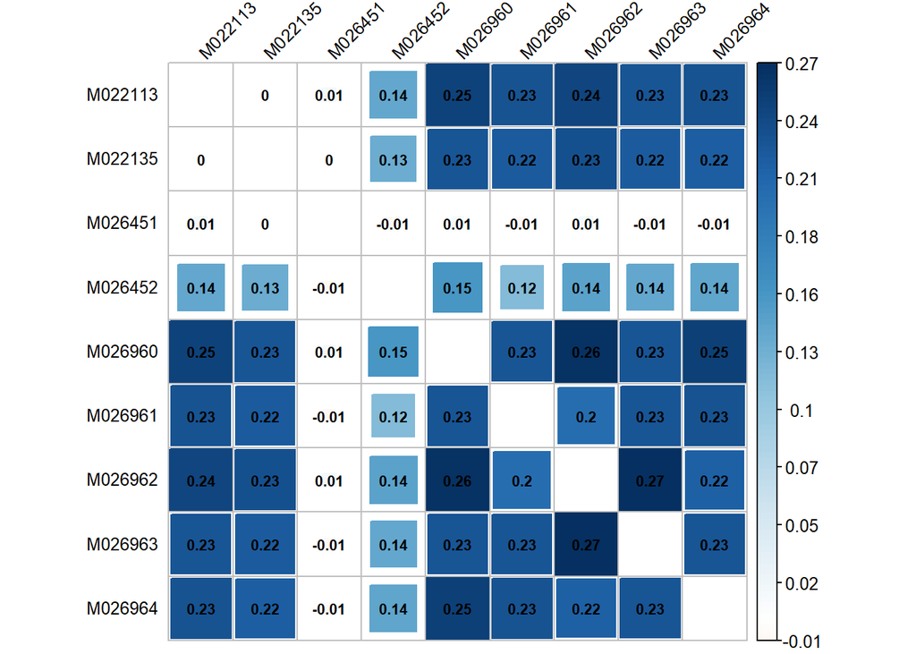

```r
# M026452
sibs <- mp$id[mp$dadid == 'M022113' & mp$momid=='M022135' & !is.na(mp$dadid) & !is.na(mp$momid)] # get family
sibs <- c(sibs,'M022113','M022135') # get parents too
tmpb <- b[rownames(b) %in% sibs, rownames(b) %in% sibs ]
colnames(tmpb) <-rownames(tmpb)
corrplot(as.matrix(tmpb),method='square',is.corr = F, diag=F,tl.col='black',
         addCoef.col = 'black',tl.cex=0.8,tl.srt=45,number.cex = 0.7)
```

Here we can see that M026451 is unrelated while M026452 is a bit related with parents / siblings. This degree of relatedness can come from a double first cousin like this:

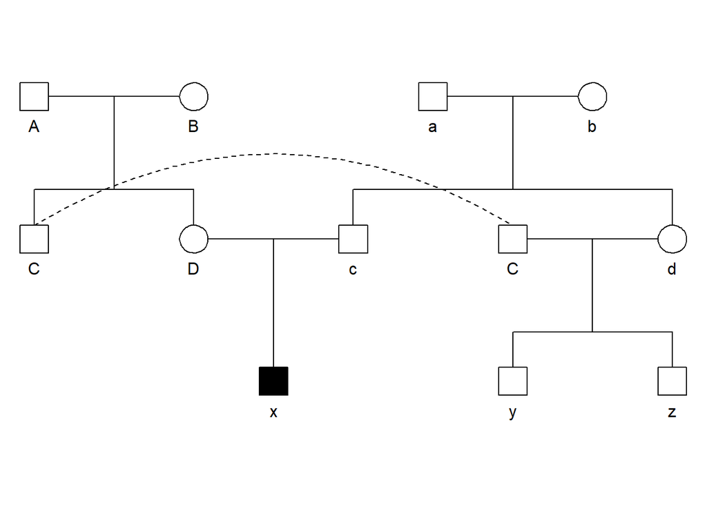

Where y and z are the clutch in question and X our individual. However because the individual has a nasty beta with himself of 0.33 we need to be careful! We also do not have genetic information for the siblings of the parents so we do not really know who the parents of this bird are.

```r
#M026451
tmp <- mp[mp$id=='M026478',] # make line for M026451
tmp[,1] <- 'M026451' # change name
mp[mp$id=='M026451',] <- tmp # replace
```

- **M031892 and M031893**. These are either twins or a sequencing error. One offspring is expected to be male and the other female. Genetically both individuals are females so we can assume that they are indeed both M031892! (**remove M031893 from the dataset**)

```r
inds <- inds[inds != 'M031893']
b <- b[rownames(b) %in% inds,rownames(b) %in% inds] # new beta matrix without the guy
```

- **M026361 and M032015**. Individuals were expected with a b=0.25 but are unrelated. This probably stems from above **M026357 and M026361**. This means that a link expected is not true hinting that probably the library of M026361 is the erroneous one….We can assume that M026361 was never sequenced instead M026357 was sequenced twice. **remove M026361 from the dataset**

```r
inds <- inds[inds != 'M026361']
b <- b[rownames(b) %in% inds,rownames(b) %in% inds] # new beta matrix without the guy
```

- **M032025**. This guys is related to an inbred father who mated with his daughter and thus is related to both the mother and father of the 2nd gen clutch leading to an elevated beta with his grandkids/grand-grandkids. His relationship with the father can be seen from k0 = 0.361 and k1 =0.411 which looks like a sibling link. Thus we just make his parents be the parents of M022673. Since both guys come from unknown clutches we have to add some extra founders.

```r
# M032025
mp[mp$id=='M022673',2] <- 'unknwn5'
mp[mp$id=='M022673',3] <- 'unknwn6'
mp[mp$id=='M032025',2] <- 'unknwn5'
mp[mp$id=='M032025',3] <- 'unknwn6'
mp <- rbind(mp,add.founder('unknwn5',1))
mp <- rbind(mp,add.founder('unknwn6',2))
```

- **M031523 and M032219**.These guys look like siblings. k0 = 0.323 and k1 = 0.474 . Both come from an unknown clutch and were recruited in the reproductive stage at the same year.

```r
# M031523 and M032219
mp[mp$id=='M031523',2] <- 'unknwn7'
mp[mp$id=='M031523',3] <- 'unknwn8'
mp[mp$id=='M032219',2] <- 'unknwn7'
mp[mp$id=='M032219',3] <- 'unknwn8'
mp <- rbind(mp,add.founder('unknwn7',1))
mp <- rbind(mp,add.founder('unknwn8',2))
```

```r
# M032251 and M038012
mp[mp$id == 'M038012',]
tmp <- mp[mp$dadid=='M032393_1' & ! is.na(mp$dadid) ,] # only get 1 clutch
tmp <- tmp[5:nrow(tmp),]
tmp[,2] <- rep('M032251',nrow(tmp)) # replace father
mp[mp$id %in% tmp$id,] <- tmp # replace in ped
```

- **M043617-M043618-M043618-M043619-M043620 siblings**. This is a CF problem. Individuals were supposed to be super-inbred but are instead unrelated to their parents and all siblings (not all were expected to be siblings instead 2 sibships were expected 17-20 and 18-19). Here they are all siblings and we can add two founder parents.

```r
# M043617-M043618-M043618-M043619-M043620
sibmess <- c('M043617','M043618','M043618','M043619','M043620')
mp[mp$id %in% sibmess, 2] <- 'unknwn9'
mp[mp$id %in% sibmess, 3] <- 'unknwn10'
mp <- rbind(mp,add.founder('unknwn9',1))
mp <- rbind(mp,add.founder('unknwn10',2))
```

Now we can recalculate the kinship matrix from the modified pedigree and re-compare the two.

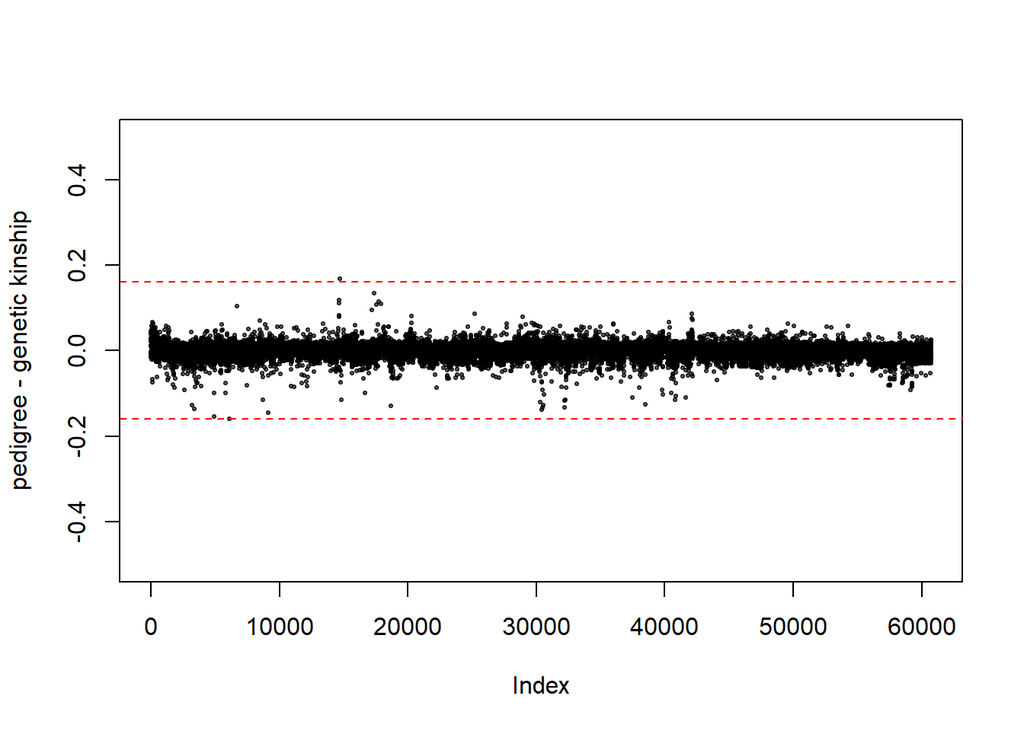

```r
bl <- update.diff(mp,b)
kmp <- kinship(mp$id,mp$dadid,mp$momid)
binmp <- match(rownames(b), rownames(kmp))
kmp <- kmp[binmp,binmp]
plot.diff(diff.k(kmp,b),0.16)
```

```r
kable(bl,caption = 'Bad links - update2' )
```

Bad links - update2

| ind1 | ind2 | bg | bp |
| --- | --- | --- | --- |
| M026452 | M026452 | 0.3318238 | 0.5 |

All that is left is that M026452 which we have to decide what to do with.  
Lets remove him for now.

```r
inds <- inds[inds != 'M026452']
b <- b[rownames(b) %in% inds,rownames(b) %in% inds]
```

Now we can write a list of individuals to keep along with an updated pedigree in two files.

Also lets make a succint pedigree that can be plotted !

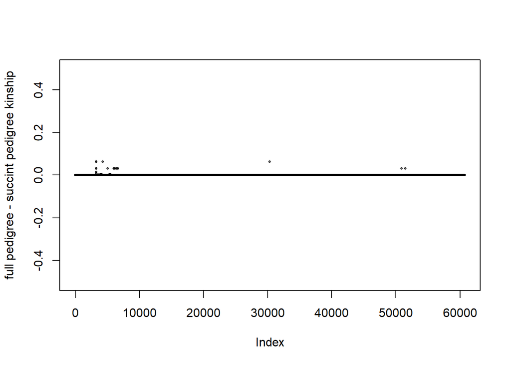

```r
# make sequenced factor for new pedigree
mp$seq <- 0
mp$seq[which(mp$id %in% metadata$NEWname)] <- 1
# WRITE FILES __ UNCOMMENT FOR SUCCESS
write.csv(mp,'genetically_fixed_pedigree.csv',quote=F, row.names = F)
write.csv(metadata[match(rownames(b),metadata$NEWname),],'individuals_to_keep.csv',quote=F, row.names =F)

# PLOTS and Succint ped
pp <- mp[mp$seq == 1,] # plotting pedigree
# add generations
tmpp <- mp[! mp$id %in% pp$id & mp$id %in% pp$dadid & ! is.na(mp$dadid),  ] # add 1 generation of dads
pp <- rbind(pp,tmpp)
tmpp <- mp[! mp$id %in% pp$id & mp$id %in% pp$momid & ! is.na(mp$momid),  ] # add 1 generation of moms
pp <- rbind(pp,tmpp)
# add founders
founders <- c(unique(pp$dadid[! pp$dadid %in% pp$id & ! is.na(pp$dadid)]), # dads that do not exist in id
              unique(pp$momid[! pp$momid %in% pp$id & ! is.na(pp$momid)])) # moms that do not exist in id
males <- length(unique(pp$dadid[! pp$dadid %in% pp$id & ! is.na(pp$dadid)]))
founders.df <- data.frame('id'=founders, 'dadid'=rep(NA,length(founders)),
                          'momid'=rep(NA,length(founders)),
                          'sex'=c(rep(1,males), rep(2,length(founders)-males)),
                          'seq'=rep(0,length(founders)))
pp <- rbind(pp,founders.df)
ppk <- kinship(pp$id, pp$dadid,pp$momid) # kinship of this ped
# comparison of kinship of total ped with this ped to see if we are missing a lot of links
kmpinpp <- match(rownames(kmp), rownames(ppk))
dtmp <- diff.k(kmp,ppk[kmpinpp,kmpinpp])
plot(dtmp[upper.tri(dtmp,diag=T)], pch=20, col = add.alpha('black',0.6),cex=0.6,
       ylab='full pedigree - succint pedigree kinship',ylim =c(-0.5,0.5))
```

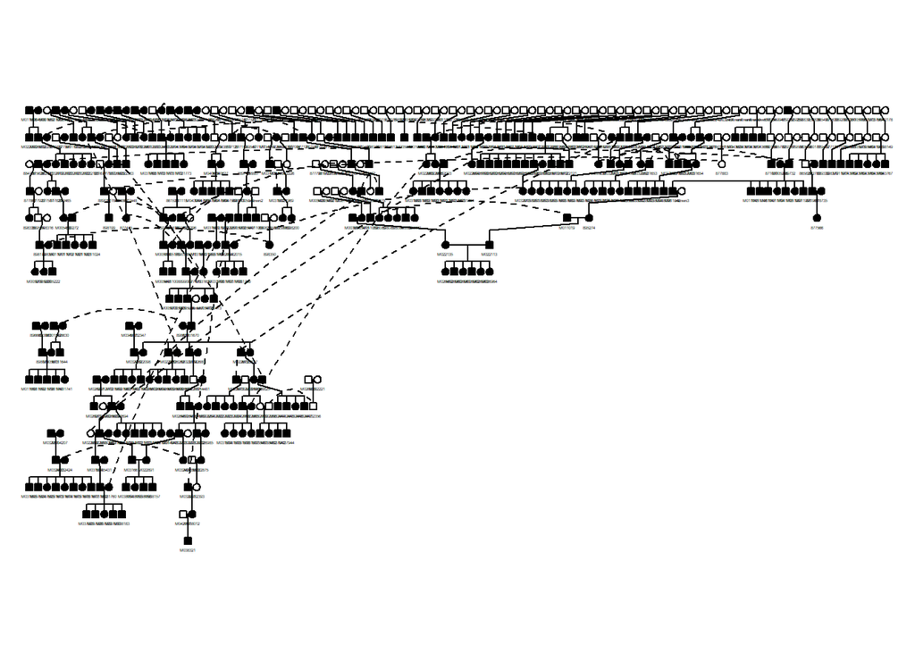

```
## Did not plot the following people: 877921 M005221 M022674 M028838 M032487 M032220 M037758 M037759 M037761
```

```r
# looks oK
pp.ped <- pedigree(pp$id,pp$dadid,pp$momid,pp$sex,pp$seq)
plot(pp.ped,cex=0.2)
```

```r
# plot them in PDF UNCOMMENT FOR SUCCESS
pdf('succint_sequenced_ped.pdf',height=10,width=24)
plot(dtmp[upper.tri(dtmp,diag=T)], pch=20, col = add.alpha('black',0.6),cex=0.6,
       ylab='full pedigree - succint pedigree kinship',ylim =c(-0.5,0.5))
abline(h=0,lty=2)
abline(h=0.1,lty=2)
abline(h=0.2,lty=2)
plot(pp.ped,cex=0.4,symbolsize = 0.6)
```

```
## Did not plot the following people: 877921 M005221 M022674 M028838 M032487 M032220 M037758 M037759 M037761
```

```r
dev.off()
```

Individuals that have been blacked out are sequenced ones (not kept but overall sequenced)… This captures almost all of our links while being small enough to be plot-able.

Cheers!